# The Chip Analysis Methylation Pipeline

Yuan Tian, Morris TJ, Butcher L, Feber A, Teschendorff A, Chakravarthy A, Beck S

2016-09-02

# 1 Introduction

The ChAMP package is a pipeline that integrates currently available 450k and EPIC analysis methods and also offers its own novel functionality. It utilises the data import from .idat file and normal beta matrix; Quality Control Plots; SWAN<sup>1</sup> and Functional Normalization<sup>2</sup> functions offered by the minfi<sup>3</sup> package.

In addition, the ChAMP package includes the Peak Based Correction (PBC) method<sup>4</sup> and the BMIQ Normalization<sup>5</sup> is set as the default method.

A number of other pipelines and packages are available for 450k or EPIC array analysis including IMA<sup>6</sup>, minfi<sup>3</sup>, methylumi<sup>7</sup>, RnBeads<sup>8</sup> and watermelon<sup>9</sup>. However, ChAMP provide a comprehensive and compelete analysis pipeline from origin data file to final GSEA result, which would make other researchers’ work much easyer. Also, the new version ChAMP provided Shiny-based WebBrower Interactive analysis function, which should benifit even more scientists.

There are also some other advantages for ChAMP. First of all ChAMP is both available for both 450k or EPIC array. Also this package contains multiple novel functions. The singular value decomposition (SVD) method<sup>10</sup> allows an in-depth look at batch effects and for correction of multiple batch effect the ComBat method<sup>11</sup> has been implemented. For the identification of differentially methylated regions (DMRs) ChAMP offers the new Probe Lasso method<sup>12</sup>. Also another two effective DMR detection function Bumphunter<sup>13</sup> and DMRcate<sup>14</sup> is also integrated and set default option.

For the purpose of dealing with cell heterogeneity problem, we included two functions RefFreeEWAS<sup>15</sup> and RefbaseEWAS<sup>16</sup> into ChAMP. Finally, ChAMP has an additional function to analyse 450k or EPIC for copy number alterations<sup>17</sup>.

Above are functions exist already in old version ChAMP, which all have been enhanceed and checked carefully. Also, some new functions are included as well:

For users who need to find methylation Blocks<sup>18</sup>. New version ChAMP included a function to detect methylation Blocks. Another important function is GSEA, which would take genes related into DMPs and DMRs and do GSEA analysis. To see what pathways are enriched by significant CpGs or DMRs. Also, new version ChAMP incoporated FEM package<sup>19</sup>, which would calculate modules in pathways show differentially methylation changes between two phenotypes.

> Apart from that, new version ChAMP provide a [Shiny](http://shiny.rstudio.com/) and [Plotly](https://plot.ly/) based GUI framework, to help scientists to view ChAMP result. This is a interactive WebBrower based framework, call for Graph System locally or remotely. For example X11 for most Linux System.

# 2 Installation

It is essential that you have `R 3.3` or above version already installed on your computer. ChAMP is a pipeline that utilises many Bioconductor packages that are currently available from CRAN and Bioconductor. For all of the steps of the pipeline to work make sure that you have ungraded Bioconductor to newest version (3.3) .

```bash
source("https://bioconductor.org/biocLite.R")
biocLite("ChAMP")
```

If you have any problem with traffic with Bioconductor, the other option is install **ALL** dependence packages, then install ChAMP. There are a lot if packaged relied by ChAMP. You can use following command in R to install most of them:

```r
source("http://bioconductor.org/biocLite.R")
biocLite(c("minfi","ChAMPdata","Illumina450ProbeVariants.db","sva","IlluminaHumanMethylation450kmanifest","limma","RPMM","DNAcopy","preprocessCore","impute","marray","wateRmelon","plyr","GenomicRanges","RefFreeEWAS","qvalue","isva","doParallel","bumphunter","quadprog","shiny","shinythemes","plotly","RColorBrewer","DMRcate","dendextend","IlluminaHumanMethylationEPICmanifest","FEM","matrixStats"))
```

> **Note** that ChAMP call for newest version FEM package [FEM_3.1.0.tar.gz](http://www.bioconductor.org/packages/devel/bioc/html/FEM.html) instead of version 2.8.0/. If you failed to install version 3.1.0, you may need to download FEM_3.1.0.tar.gz package and install it with following code:

```bash
R CMD INSTALL FEM_3.1.0.tar.gz
```

After you did all above work, you may use code below to install ChAMP:

```bash
R CMD INSTALL ChAMP_2.0.1.tar.gz
```

# 3 Test Data

The package contains a test dataset of HumanMethylation450 data which can be used to test functions available in ChAMP. This can be loaded by pointing the directory to the testDataSet:

```r
testDir=system.file("extdata",package="ChAMPdata")
```

This dataset contains only 8 Samples, we will use it to show ChAMP functions’ usage blow.

# 4 Full Pipeline

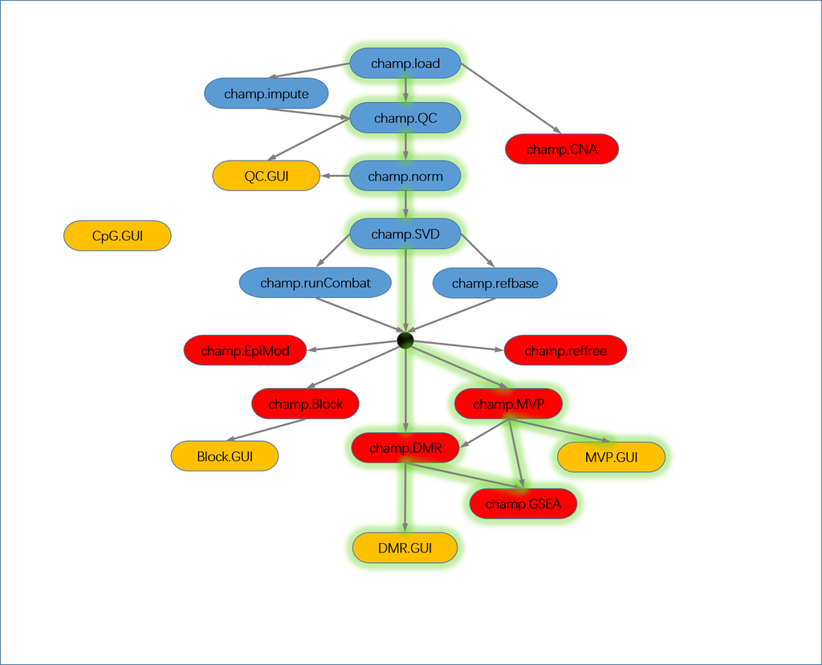

ChAMP Pipeline Figure above outlines the steps in the ChAMP pipeline. Each step can be run individually as a separate function. This allows integration with other analysis pipelines. It also enables the user to save the results of each step for future reference or further analysis. Alternatively the full pipeline can be run at once with one command:

```r
champ.process(directory = testDir)
```

When running the full pipeline through the champ.process() function a number of parameters can be adjusted. These parameters are related to all functions involved in ChAMP package, but not all parameters are covered, otherwise champ.process() function would be be too large.

> Note that champ.process() may not always successfully run, because any small mistake on data set in it may result to Error. So if you get any problem in champ.process() you may try separated steps below.

# References

1. Maksimovic J et a. SWAN: Subset-quantile within array normalization for illumina infinium humanmethylation450 beadchips. *Genome Biol*. 2012;13(6):R44.

2. Fortin J-P, Labbe A, Lemire M, et al. Functional normalization of 450k methylation array data improves replication in large cancer studies. *Genome Biology*. 2014;15(11):1-17.

3. Hansen K, Ayree M. Analyzing Illumina 450k Methylation Arrays. 2011.

4. Dedeurwaerder S et a. Evaluation of the infinium methylation 450K technology. *Epigenomics*. 2011;3(6):771-784.

5. Teschendorff AE et al . A beta-mixture quantile normalization method for correcting probe design bias in illumina infinium 450 k dna methylation data. *Bioinformatics*. 2013;29(2):189-196.

6. Wang D et a. IMA: An r package for high-throughput analysis of illumina’s 450K infinium methylation data. *Bioinformatics*. 2012;28(5):729-730.

7. Davis S, Du P, Bilke S, Triche T, Jr., Bootwalla M. Methylumi: Handle illumina methylation data. 2013.

8. Assenov Y, Muller F, Lutsik P. RnBeads - Comprehensive DNA Methylation Analysis. 2012.

9. Wong C, Pidsley R, Schalkwyk L. The wateRmelon Package. 2012.

10. Teschendorff AE et a. An epigenetic signature in peripheral blood predicts active ovarian cancer. *PLoS One*. 2009;4(12):e8274.

11. Johnson WE et a. Adjusting batch effects in microarray expression data using empirical bayes methods. *Biostatistics*. 2007;8(1):118-127.

12. Butcher LM, Beck S. Probe lasso: A novel method to rope in differentially methylated regions with 450K dna methylation data. *Methods*. 2015;72:21-28.

13. Jaffe AE et a. Bump hunting to identify differentially methylated regions in epigenetic epidemiology studies. *Int J Epidemiol*. 2012;41(1):200-209.

14. Peters TJ, Buckley MJ, Statham AL, et al. De novo identification of differentially methylated regions in the human genome. *Epigenetics & Chromatin*. 2015;8(1):1-16.

15. Houseman EA, Molitor J, Marsit CJ. Reference-free cell mixture adjustments in analysis of dna methylation data. *Bioinformatics*. 2014;30(10):1431-1439.

16. Houseman EA, Accomando WP, Koestler DC, et al. DNA methylation arrays as surrogate measures of cell mixture distribution. *BMC Bioinformatics*. 2012;13(1):1-16.

17. Feber A, Guilhamon P, Lechner M, et al. Using high-density dna methylation arrays to profile copy number alterations. *Genome Biol*. 2014;15(2):R30.

18. Berman BP AJ Weisenberger DJ. Regions of focal dna hypermethylation and long-range hypomethylation in colorectal cancer coincide with nuclear lamna- associated domains. *Nat Genet*. 44:40-46.

19. Jiao Y, Widschwendter M, Teschendorff AE. A systems-level integrative framework for genome-wide dna methylation and gene expression data identifies differential gene expression modules under epigenetic control. *Bioinformatics*. 2014;30(16):2360-2366.